# Plotting

# EXERCISE: CREATE A LAYOUT AS THE ONE SHOWN IN FIGURE

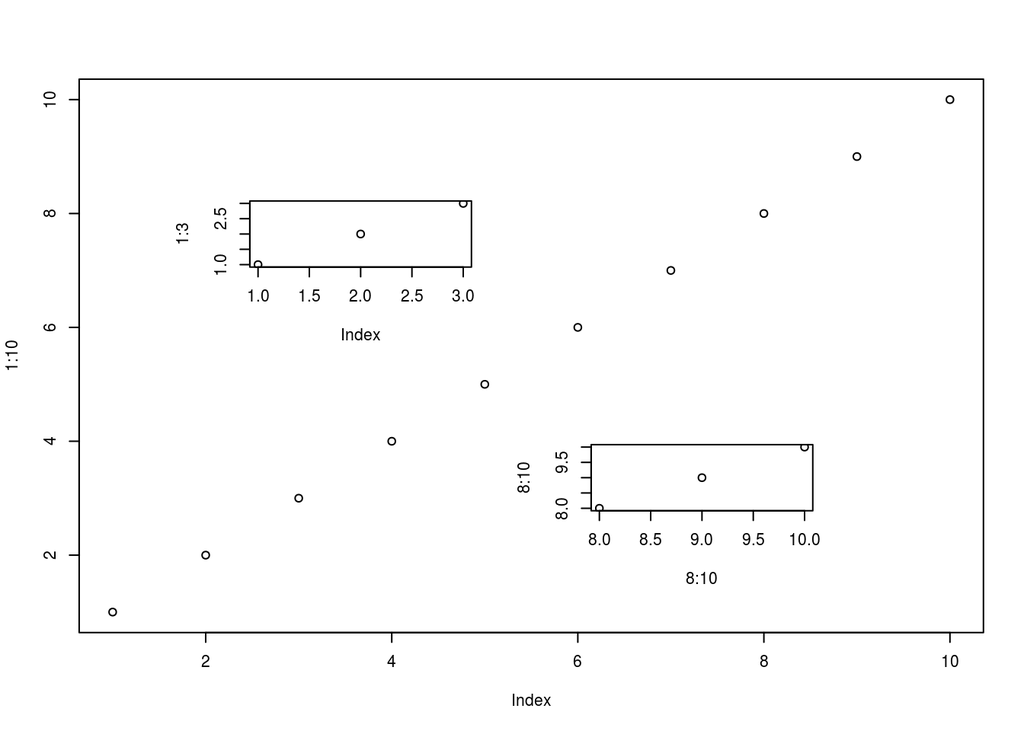

## **Saving your plot**

There are several ways. You can save the plot in the ACTIVE device as a pdf file using:

```r
dev.copy2pdf(file="my.plot_layout.pdf")
```

And there are other functions for saving the ACTIVE device using other formats:

```r
win.metafile("mygraph.wmf")     #windows metafile
png("mygraph.png")  #png file
jpeg("mygraph.jpg")     #jpeg file
bmp("mygraph.bmp")  #bmp file
postscript("mygraph.ps")    #postscript file
```

Alternatively, you can produce the plot directly to a file. For example, using the pdf() function will generate a pdf file in your computer. From that point, all the plotting functions will be applied to this file. You will not be able to open the file (and see your plot) unless you close the conection between the R and the file using dev.off(). Here is an example:

```r
# first create the pdf and then plot "on it"

pdf("mygraph.pdf")
plot(1:2)
# Nothing happens, but a file is created.
# However, you can't open it
dev.off()
# Now you can
```

## **Plot types and arguments**

There are multiple functions to perform different plots. Many of them share arguments to set particular issues -such as colors (col), size (cex),..- and other arguments are specific of every function.

In this section we briefly describe some of the functions (and few of their argruments) to perform plots.

# *Scatterplots*

Let’s explore some options of plots using the bumpus dataset. The first step is to import and visualize the data:

```r
bumpus <- read.csv("bumpus.csv")
str(bumpus)
```

```
## 'data.frame':    136 obs. of  13 variables:
##  $ subject : int  1 1 2 2 3 3 4 4 5 5 ...
##  $ sex     : Factor w/ 2 levels "f","m": 2 2 2 2 2 2 2 2 2 2 ...
##  $ age     : Factor w/ 3 levels "","a","y": 2 2 2 2 2 2 2 2 2 2 ...
##  $ survived: logi  TRUE FALSE FALSE TRUE TRUE FALSE ...
##  $ TL      : int  154 165 160 160 155 161 154 162 156 163 ...
##  $ AE      : int  241 240 245 252 243 249 245 246 247 250 ...
##  $ WT      : num  24.5 26.5 26.1 26.9 26.9 25.6 24.3 25.9 24.1 25.5 ...
##  $ BHL     : num  31.2 31 32 30.8 30.6 32.3 31.7 32.3 31.5 32.5 ...
##  $ HL      : num  17.4 18.7 18.7 18.7 18.6 ...
##  $ FL      : num  17 17.9 18 18 17.9 ...
##  $ TTL     : num  26 27.8 28.2 30 29.2 ...
##  $ SW      : num  14.9 15.4 15.5 15.3 15.3 ...
##  $ SKL     : num  21.1 21.5 21.4 21.4 21.5 ...
```

As mentioned above, if only one variable is selected, it is plotted as Y and X is an index

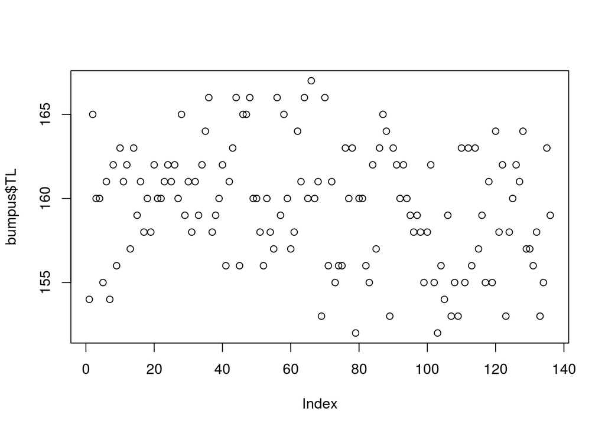

```r
plot(bumpus$TL)
```

Logical are coerced

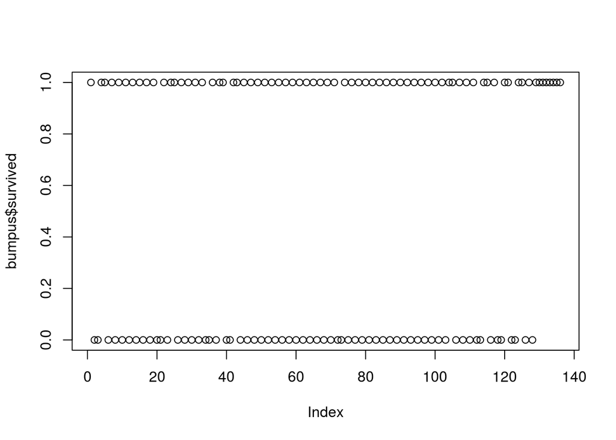

```r
plot(bumpus$survived)
```

With two variables:

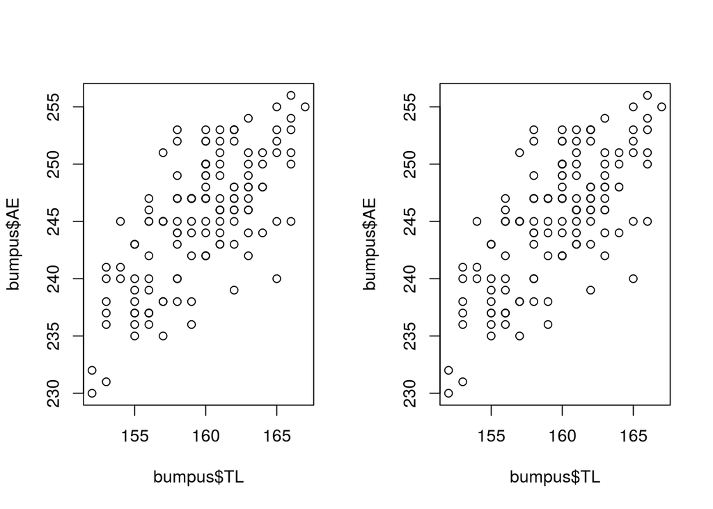

```r
layout(matrix(1:2,ncol=2))
plot(bumpus$TL, bumpus$AE)
# Note that the order is X Y
plot(bumpus$AE~bumpus$TL)
```

```r
# Note that the order is Y X
```

The scatterplot also works with large dataframes:

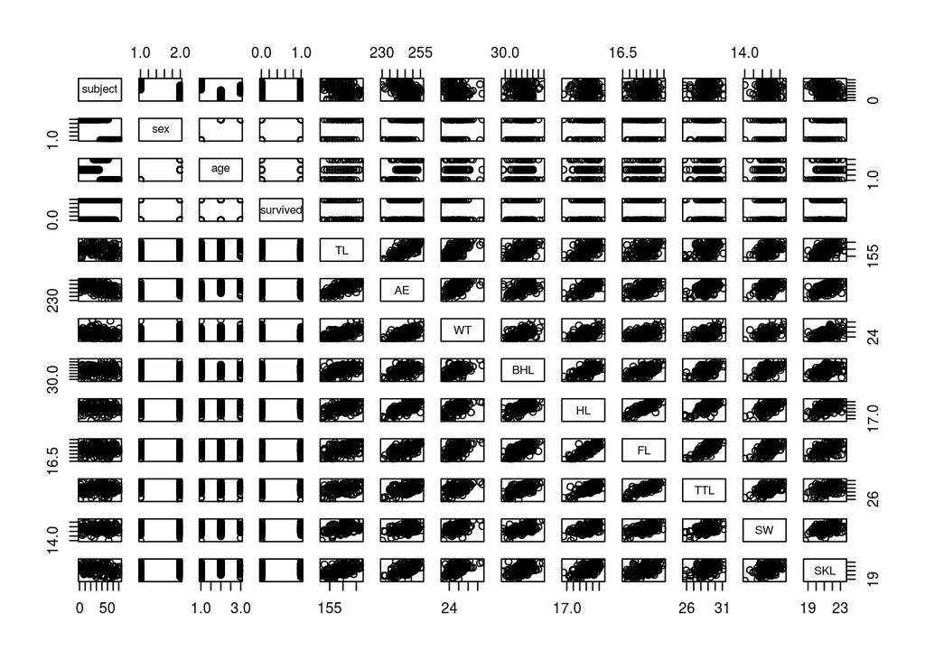

```r
# The entire bumpus dataset
plot(bumpus)
```

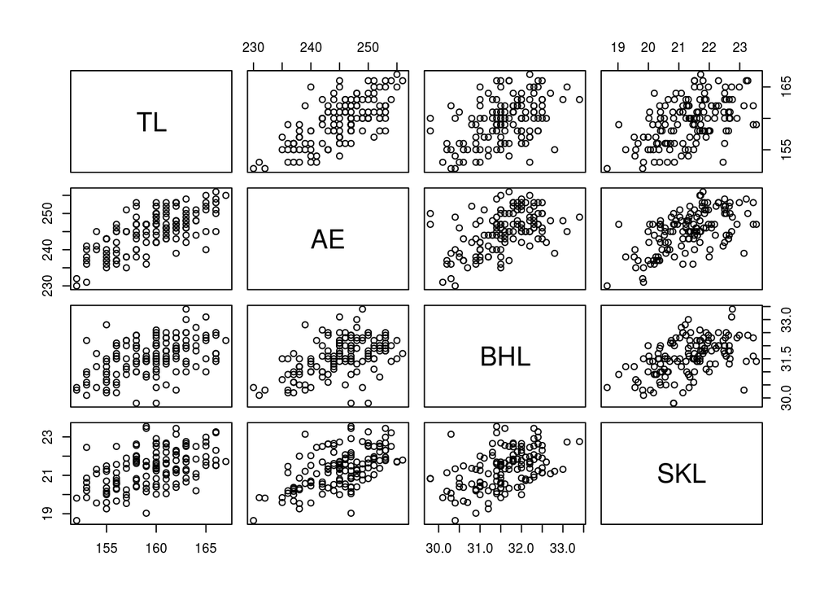

```r
# A subset
plot(bumpus[,c("TL", "AE", "BHL", "SKL")])
```

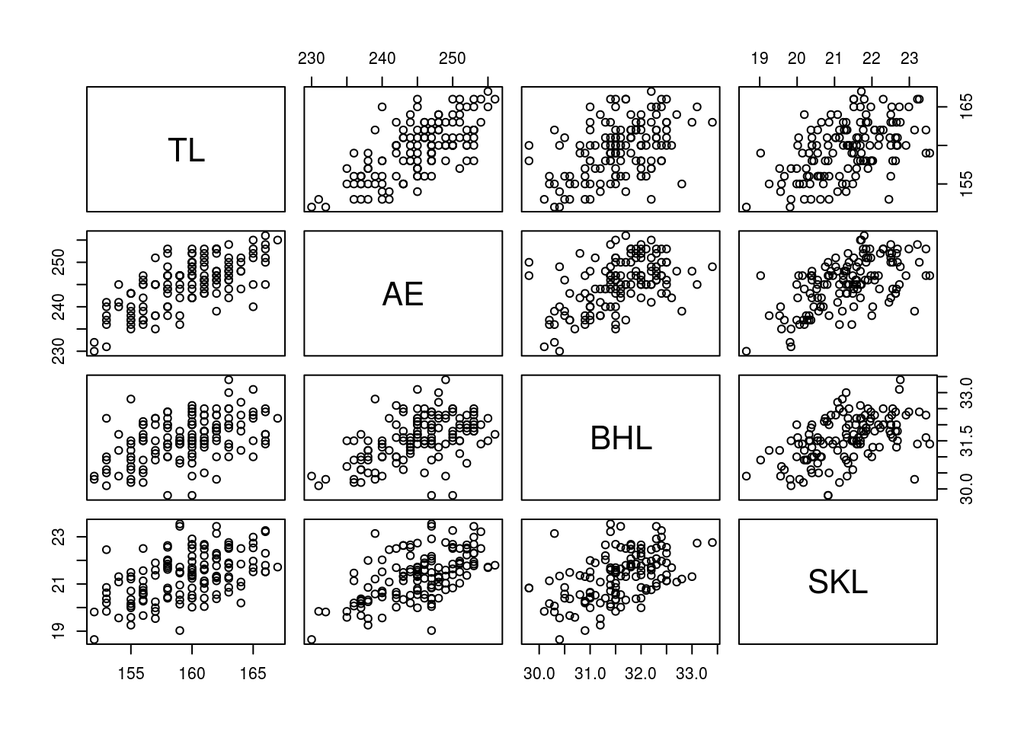

```r
# This is exactly the same
pairs(~TL+AE+BHL+SKL, data=bumpus)
```

# *DENSITY PLOTS*

See ?hist for details.

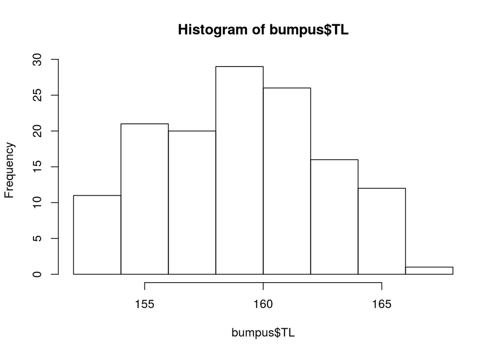

```r
hist(bumpus$TL)
```

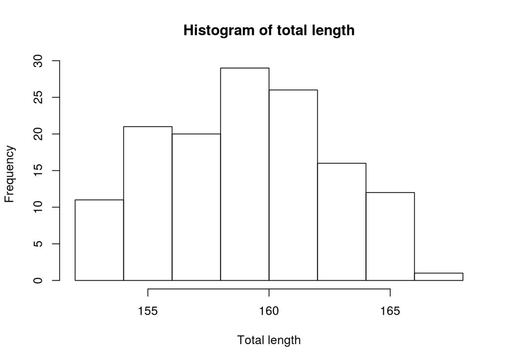

```r
hist(bumpus$TL, main="Histogram of total length", xlab="Total length")
```

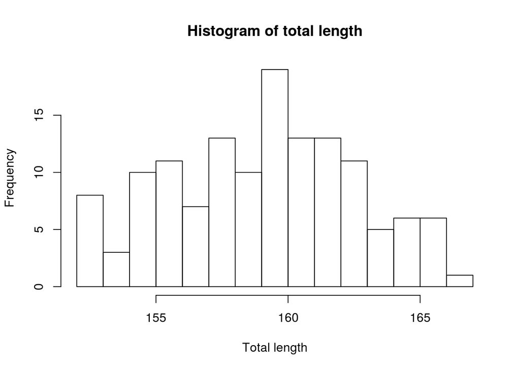

```r
hist(bumpus$TL, main="Histogram of total length", xlab="Total length",
     breaks=20)
```

# *BOXPLOTS*

See ?boxplot for details

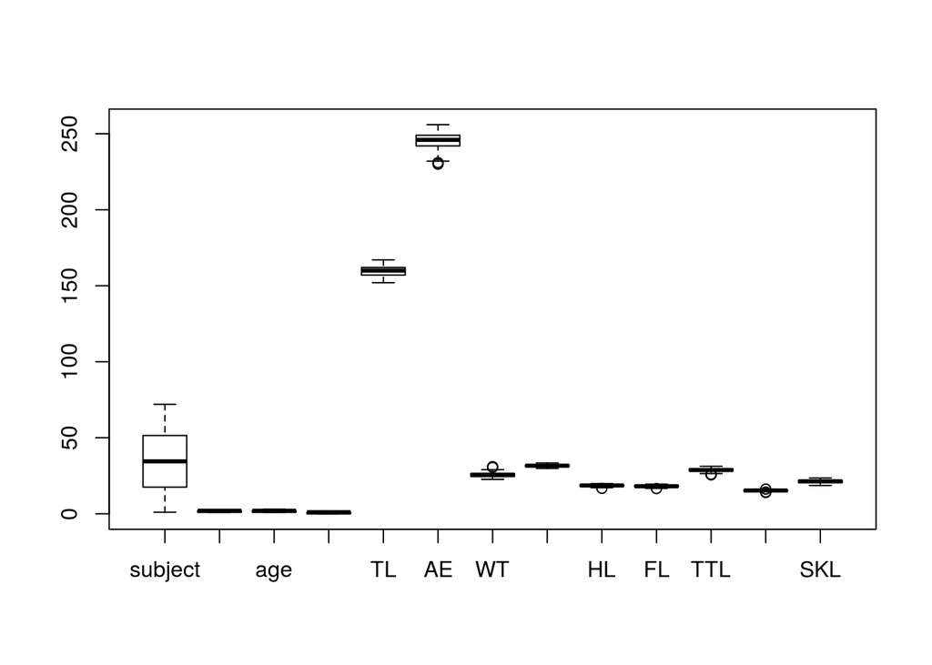

```r
boxplot(bumpus)
```

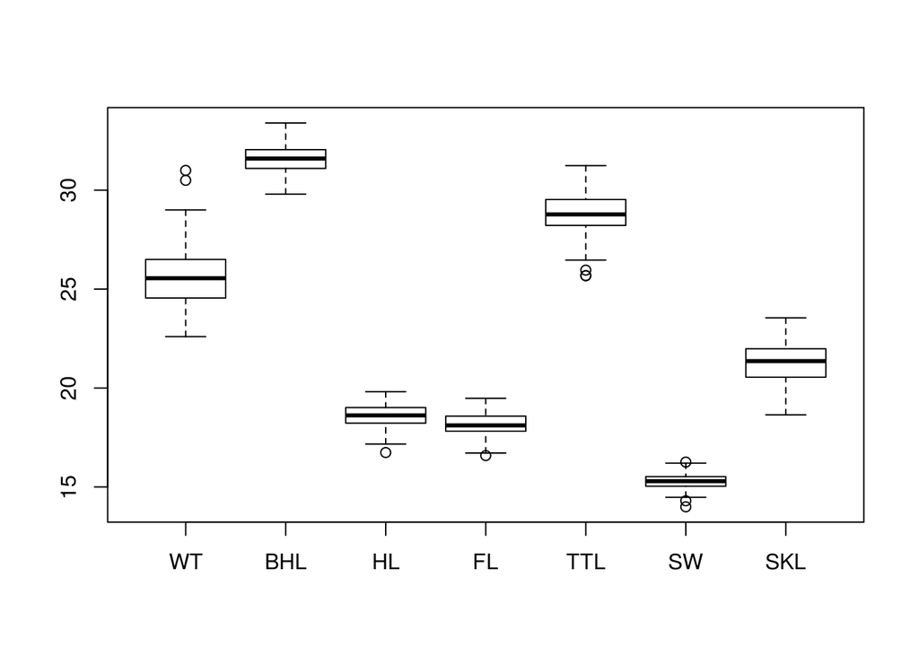

```r
boxplot(bumpus[,7:13])
```

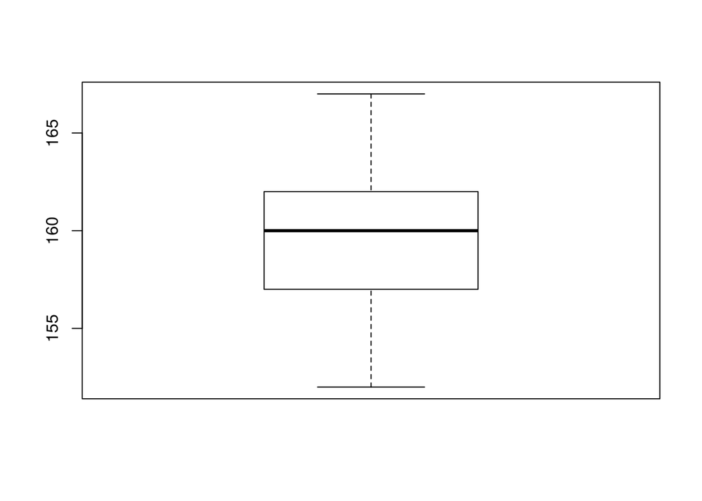

```r
boxplot(bumpus$TL)
```